# BM432 Data Visualisation Workshop

## Critique 3.6

**Issue**

Excessive length of figure legend for panel A.

**Solution**

Break out panel A into its own figure.

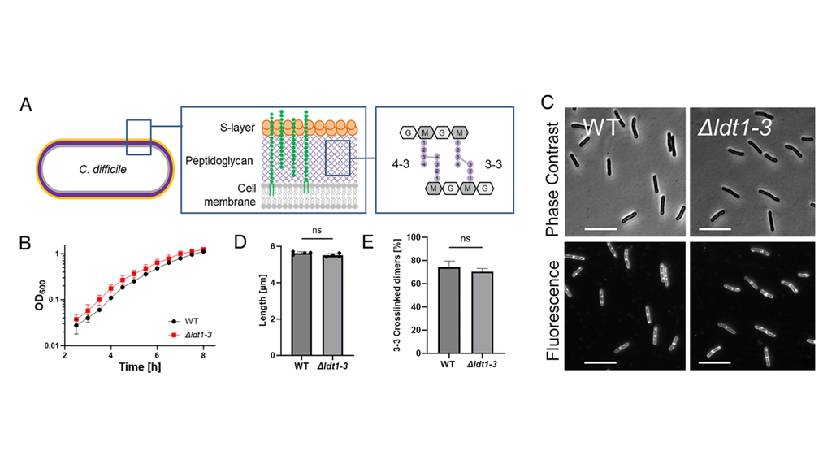

## Our Critical Analysis

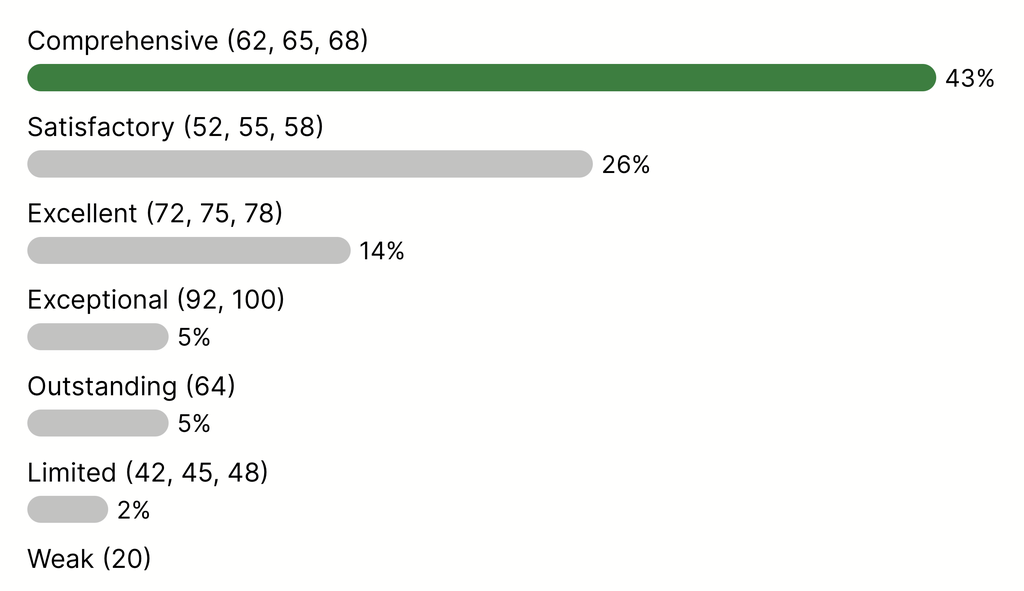

Post-survey results

## Example 4

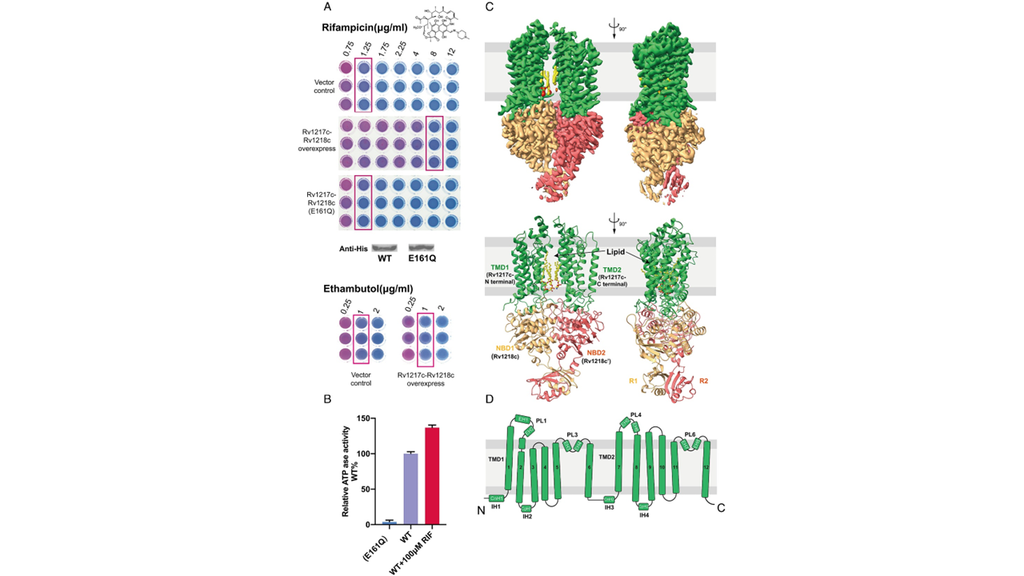

Figure 4: Functional characterization and overall structure of Rv1217c–1218c.

## Your Critical Analysis of Example 4

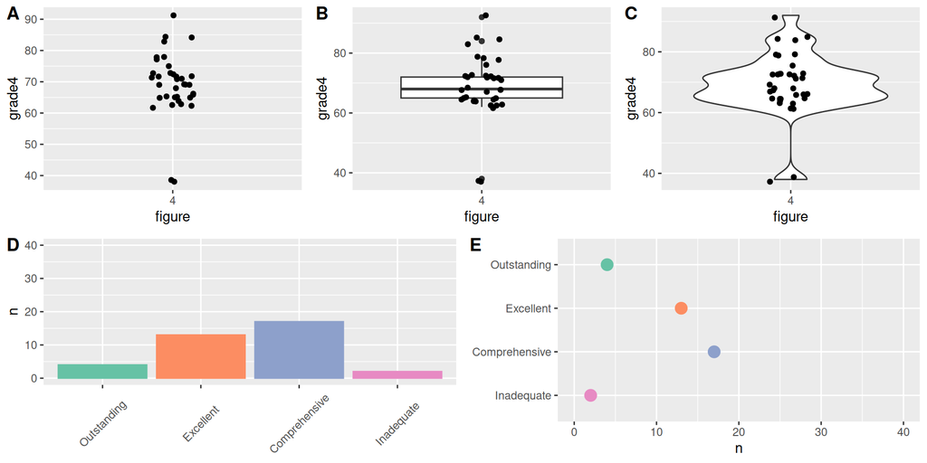

## Your Critical Analysis of Example 4

[output not shown]

## Your Critical Analysis of Example 4

[output not shown]

## Critique 4.1

**Issue**

The rifampicin structure is purely decorative.

**Solution**

Remove unnecessary elements and avoid needless distractions in figures.

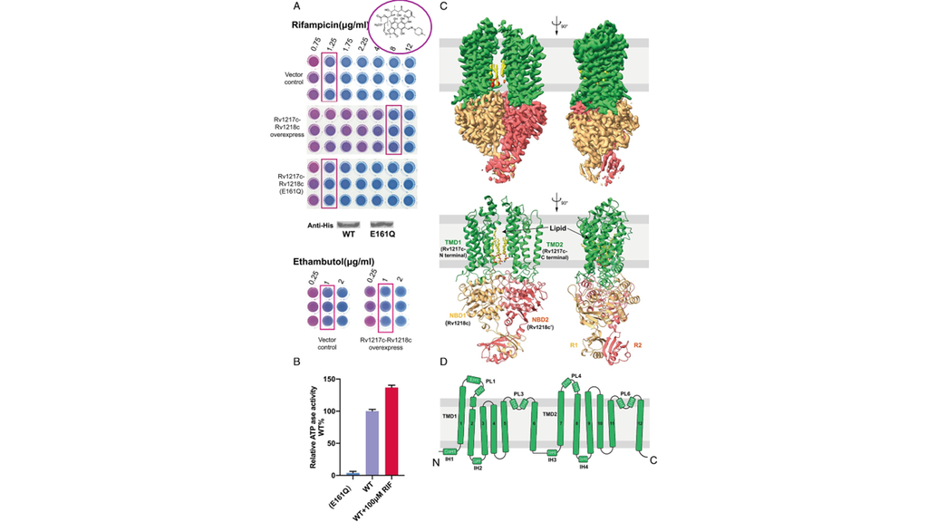

## Critique 4.2

**Issue**

Dynamite plot: the lower extent of these error bars is not visible.

**Solution**

Use boxplots or 1D scatterplots

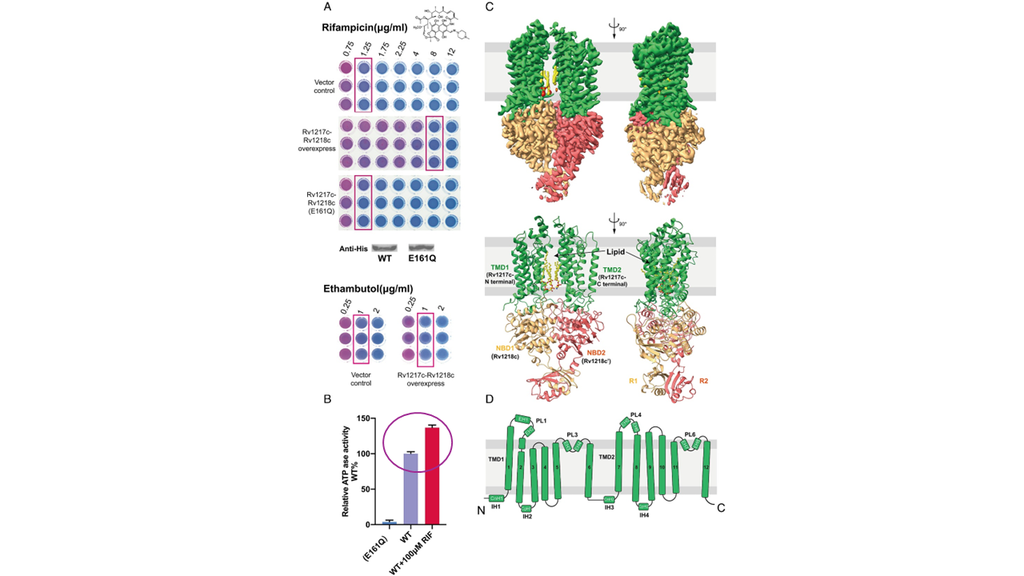

## Critique 4.3

**Issue**

Colour scheme in (B) doesn’t seem purposeful and doesn’t add anything to the figure.

**Solution**

Use colour consistently to link or distinguish elements/groups/data, rather than for decoration.

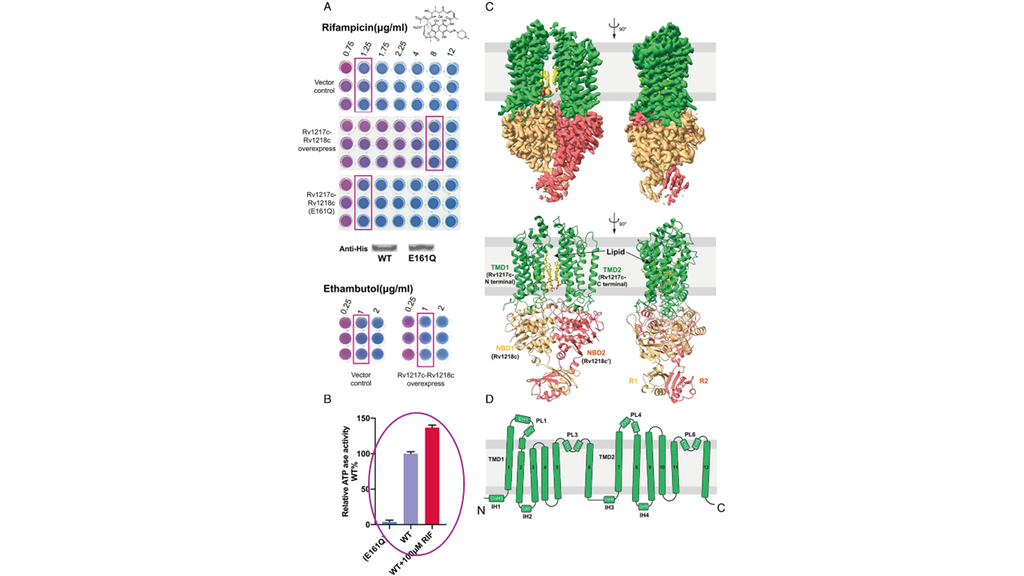

## Critique 4.4

**Issue**

The meaning of the grey regions in (C) and (D) is unclear.

**Solution**

The implied membrane in (C) and (D) could be labelled as such in the figure. By convention in microbiology, we would assume that the periplasm/extracellular space is “up” and the cytoplasm is “down” in (C) and (D) - but this should really be labelled to avoid any potential confusion.

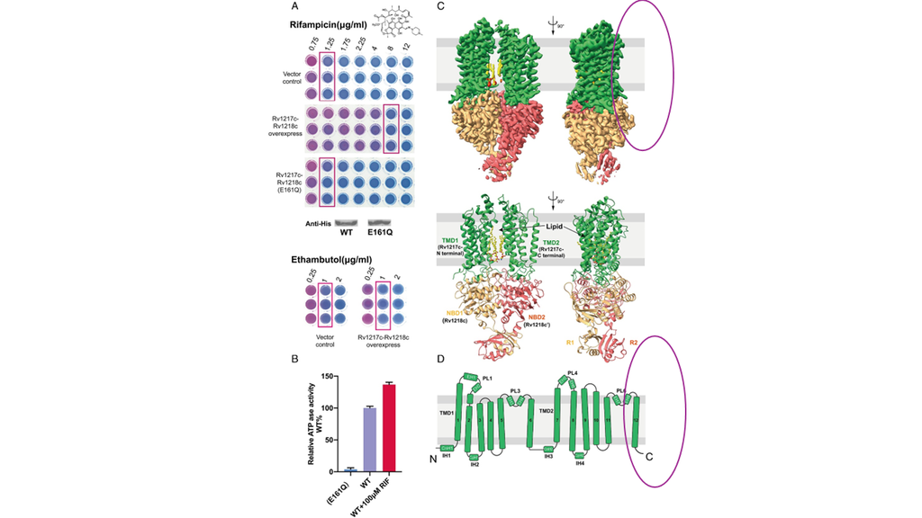

## Critique 4.5

**Issue**

Colours in (A) difficult to distinguish, especially with the red boxes which seem to skew blue closer to purple.

**Solution**

Instead of well images, a heatmap with clearer colour distinction could be presented.

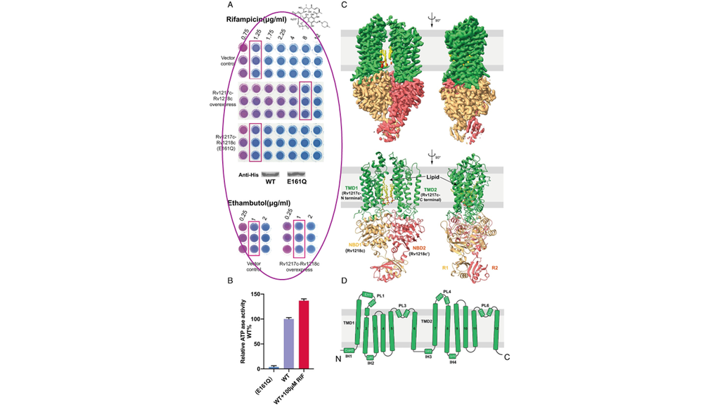

## Critique 4.6

**Issue**

Showing two cut-out bands is not an appropriate way to show Western blot data.

**Solution**

Present the complete blot.

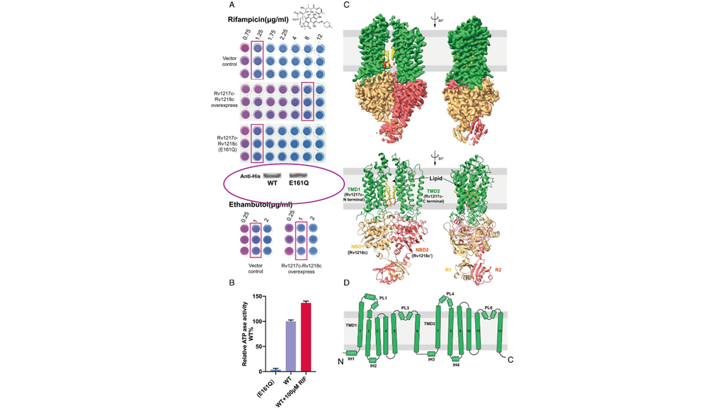

## Critique 4.7

**Issue**

Text in (D) is too small to read easily.

**Solution**

Break out panel into a separate figure or increase font size.

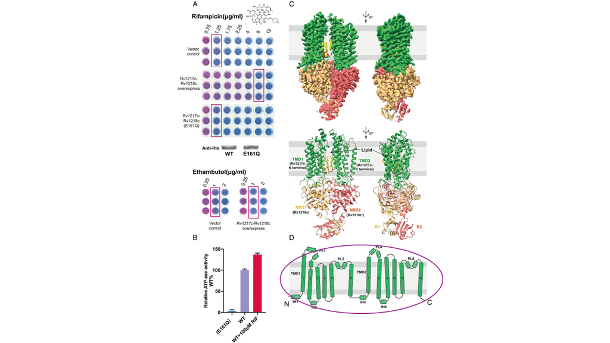

## Our Critical Analysis

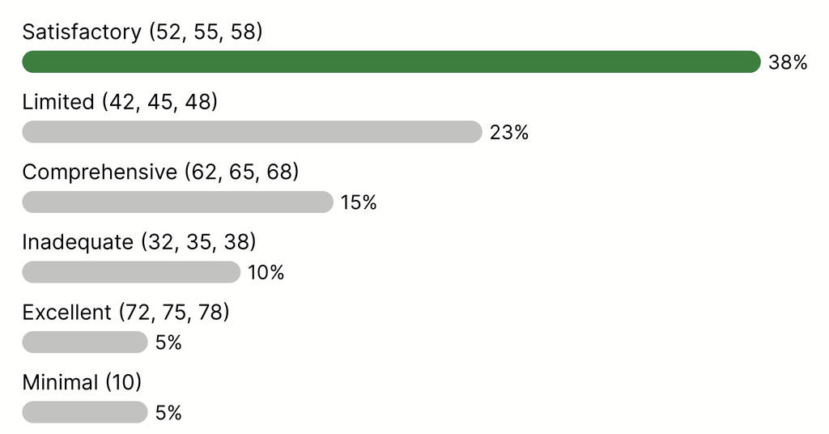

Post-survey results

# 3. Summing Up

## General Comments - Data Presentation Choices

**Issue**

Authors do not always choose the best or most appropriate way to present their data (e.g., dynamite plots)

**Solution**

When making data visualisation choices, consider how you can best present your data transparently to the reader so that they can evaluate your work (e.g., show the raw data).

Be aware of conventions in the field and discuss with colleagues to come to a consensus of the best and most transparent way to present your data.

## General Comments - Colour Choices

**Issue**

Authors do not always choose the best or most appropriate colours when designing data visualisations.

**Solution**

When choosing colours, try to:

1. Be consistent (always use the same colour to represent the same group or feature)
2. Be accessible (be aware of the different types of colourblindness and design appropriately)
3. Be aesthetically pleasing (choose colours that work well together, or choose well-designed colour palettes)

## General Comments - Readability

**Issue**

Authors do not always make figures large enough or easy to read.

**Solution**

When designing figures, make sure that they are appropriately sized and accessible (font large enough to read easily at 100% size).

Include enough space between panels of a figure that allows the figures to “breathe” - the eye should flow smoothly from one element of the figure to the next in a natural way.

Try printing out a copy of the figure and look at it from arm’s length to see how it feels in terms of whitespace and use of “real estate” - then make appropriate edits to improve the figure.

## General Comments - Message

**Issue**

Authors sometimes include too much data in a figure, or make a figure overwhelming in other ways.

**Solution**

When sitting down to make a figure, be sure to define a clear message in the first instance. Present the data that are necessary to convey that message. Remove anything extraneous. (Split into multiple figures if necessary.)

## Some Very Insightful Comments From You

- “The data is presented in a manner that would likely be inaccessible for people without prior experience. A move toward a more palatable/digestible format will facilitate better science communication in the future.”
- “I think that it is also crucially important to learn how to present data well and responsibly…”

## Further Reading

- Introduction to Data Visualisation
  - https://sipbs-compbiol.github.io/bm432-datavis_workshop
- Additional information:
  - [“Fundamentals of Data Visualisation” *by Claus O. Wilke*](https://clauswilke.com/dataviz/)
  - [“Data Visualisation: A Practical Introduction” *by Kieran Healy*](https://socviz.co/index.html#preface)
  - [“Points of View: graphic design for data visualisation”](https://communities.springernature.com/posts/data-visualization-a-view-of-every-points-of-view-column)